# Generate Predictions

Kevin Lu

November 20, 2017

# 1. Capture Command Line Arguments

This script when called through the command line using Rscript has the option of including one argument that takes the following values: predictions.

When the script is called with the predictions argument, only predictions are generated and exported to feather. This is designed to be called on a regular cadence to generate real-time predictions quickly.

When the script is called without an argument, both predictions and plots are generated. This is designed to be called using render to generate notebooks for diagnostic purposes.

```r
args_prediciton <- commandArgs(trailingOnly = TRUE)
if (length(args_prediciton) == 0) {
  args_prediciton <- "none"
}
```

# 2. Source Cross Validate Functions

Sets the command line arguments to NULL so that the command line arguments intended for this script do not get passed to the load packages script.

```r
commandArgs <- function(...) NULL
source("./Mean Reversion/RMR.010 Cross Validate Functions.R")
```

# 3. Set Parameters

```r
params <- list(time_resolution = 300,
               quote_currency = "USDT",
               cointegration_test = "eg",
               adf_threshold = -5.0,
               distance_threshold = 0.00,
               train_window = days(30),
               test_window = days(20),
               model_type = "raw",
               regression_type = "ols",
               spread_type = "rolling",
               rolling_window = 1440,
               signal_logic = "scaled",
               signal_scaled_enter = 3.0,
               signal_discrete_enter = 3.0,
               signal_discrete_exit = 0.2,
               signal_stop = 4.5,
               signal_reenter = TRUE,
               signal_reenter_threshold = 2.00,
               pair_allocation = "equal",
               pair_allocation_scaling = 1.00)
```

# 4. Query Data

```r
pricing_data <- read_csv("./Mean Reversion/Raw Data/pricing data.csv", col_types = c("iTdddddddci")) %>%
  filter(date_time <= "2017-11-17")
# mongo_connection <- mongo(collection = str_c("pricing_data_", params[["time_resolution"]],
#                           db = "poloniex_ohlc",
#                           url = "mongodb://localhost")
# pricing_data <- mongo_connection$find(query = '{}')
```

# 5. Initialize Cutoff Date

Initialize the cutoff date to split the data into a training and test set where the training set is used to select cointegrated coin pairs and predictions are made over the test set. The cutoff date is initialized to an arbitrary date which represents the date. The cutoff date is then moved forward in time so that current predictions can be made.

```r
cutoff_date <- as.Date("2017-11-01")
test_window <- days(as.numeric(str_match(params[["test_window"]], "(\\d*)d*")[, 2]))
while (Sys.Date() - test_window > cutoff_date) {
  cutoff_date <- cutoff_date + test_window
}
print(str_c("Coin pair selection last occured on ", cutoff_date, "."))
```

```
## [1] "Coin pair selection last occured on 2017-11-01."
```

# 6. Generate Predictions

```r
predictions <- generate_predictions(pricing_data = pricing_data,
                                    cutoff_date = "2017-11-01",
                                    params = params)
```

# 7. Extract Current Predictions

```r
predictions_current <- predictions %>%
  group_by(coin_y_name, coin_x_name) %>%
  filter(row_number() == n()) %>%
  select(date_unix, date_time, coin_pair_id, coin_y_name, coin_x_name, coin_y_price, coin_x_price, signal, hedge_ratio, intercept,
         coin_y_position, coin_x_position, change_y_position, change_x_position)
```

# 8. Print Predictions

```r
options(width = 160)
print(predictions_current %>% select(date_time, coin_y_name, coin_x_name, change_y_position, change_x_position))
```

```
## # A tibble: 15 x 5
## # Groups:   coin_y_name, coin_x_name [15]
##              date_time coin_y_name coin_x_name change_y_position change_x_position
##                 <dttm>       <chr>       <chr>             <dbl>             <dbl>
##  1 2017-11-17 05:00:00    USDT_REP   USDT_DASH                 0           -0.0076
##  2 2017-11-17 05:00:00   USDT_DASH    USDT_REP                 0            1.0543
##  3 2017-11-17 05:00:00    USDT_XMR   USDT_DASH                 0            0.0190
##  4 2017-11-17 05:00:00    USDT_XMR    USDT_ETH                 0            0.0387
##  5 2017-11-17 05:00:00   USDT_DASH    USDT_XMR                 0            0.6258
##  6 2017-11-17 05:00:00    USDT_REP    USDT_ZEC                 0            0.0016
##  7 2017-11-17 05:00:00    USDT_ETH    USDT_XMR                 0           -0.1609
##  8 2017-11-17 05:00:00    USDT_REP    USDT_BTC                 0            0.0047
##  9 2017-11-17 05:00:00    USDT_ZEC    USDT_REP                 0            0.1661
## 10 2017-11-17 05:00:00    USDT_XMR    USDT_REP                 0            0.0726
## 11 2017-11-17 05:00:00    USDT_XMR    USDT_LTC                 0            0.0552
## 12 2017-11-17 05:00:00    USDT_XMR    USDT_ZEC                 0            0.0216
## 13 2017-11-17 05:00:00    USDT_REP    USDT_XMR                 0           -0.0159
## 14 2017-11-17 05:00:00   USDT_DASH    USDT_ZEC                 0            0.3529
## 15 2017-11-17 05:00:00    USDT_ZEC   USDT_DASH                 0           -0.0406
```

# 8. Export Predictions

```r
if (args_prediciton == "predictions") {
  write_feather(predictions_current, "./Mean Reversion/Output/Feather/predictions.feather")
}
```

# 9. Generate Diagnostic Plots

```
## # A tibble: 15 x 3
##       coin_y    coin_x cointegration_stat
##        <chr>     <chr>              <dbl>
##  1  USDT_REP USDT_DASH          -7.912494
##  2 USDT_DASH  USDT_REP          -7.758633
##  3  USDT_XMR USDT_DASH          -7.624813
##  4  USDT_XMR  USDT_ETH          -7.500523
##  5 USDT_DASH  USDT_XMR          -6.969212
##  6  USDT_REP  USDT_ZEC          -6.320699
##  7  USDT_ETH  USDT_XMR          -6.254210
##  8  USDT_REP  USDT_BTC          -6.139231
##  9  USDT_ZEC  USDT_REP          -6.044732
## 10  USDT_XMR  USDT_REP          -5.833323
## 11  USDT_XMR  USDT_LTC          -5.495864
## 12  USDT_XMR  USDT_ZEC          -5.263797
## 13  USDT_REP  USDT_XMR          -5.194261
## 14 USDT_DASH  USDT_ZEC          -5.186005
## 15  USDT_ZEC USDT_DASH          -5.082952
## [1] "Creating plots for USDT_REP and USDT_DASH."
## [1] "Using train set from 2017-10-02 to 2017-11-01."
## [1] "Using test set from 2017-11-01 to 2017-11-21."
```

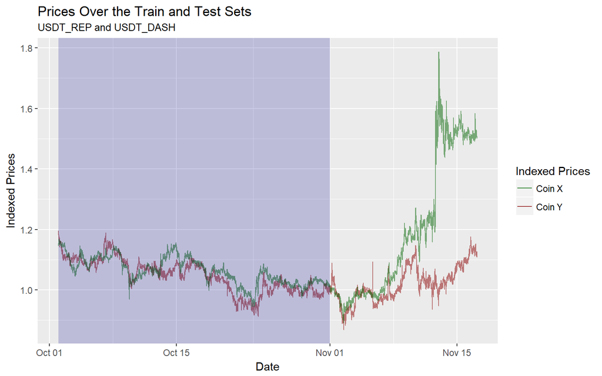

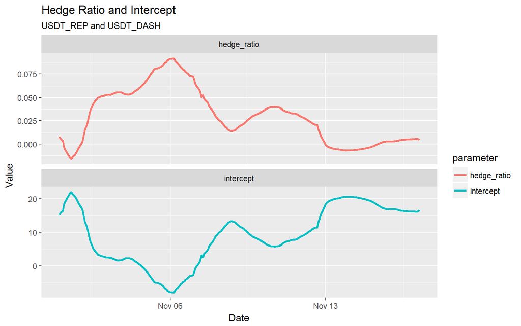

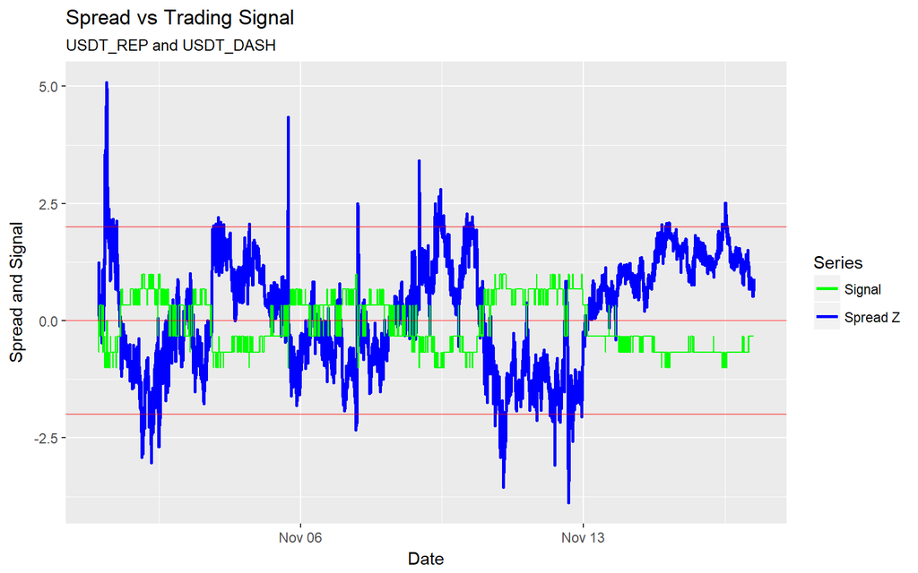

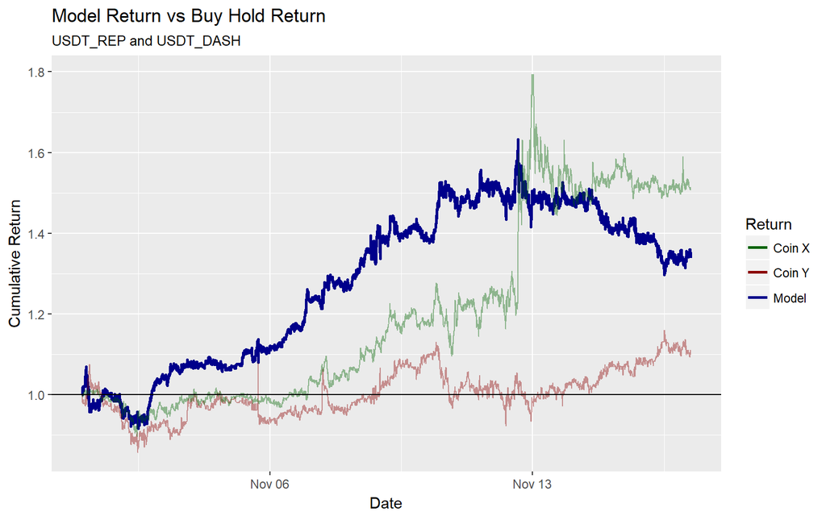

```
## [1] "Creating plots for USDT_DASH and USDT_REP."
## [1] "Using train set from 2017-10-02 to 2017-11-01."
## [1] "Using test set from 2017-11-01 to 2017-11-21."
```

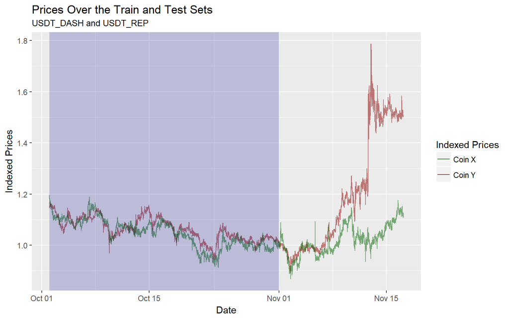

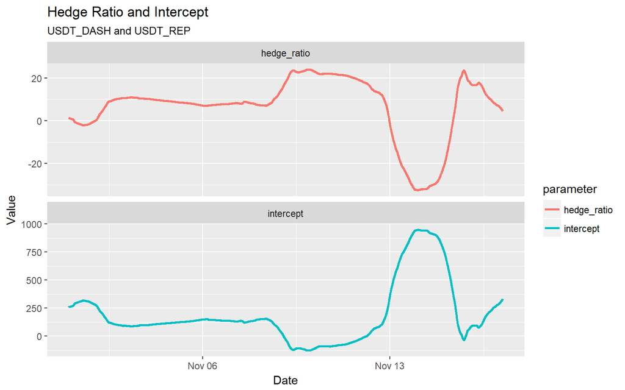

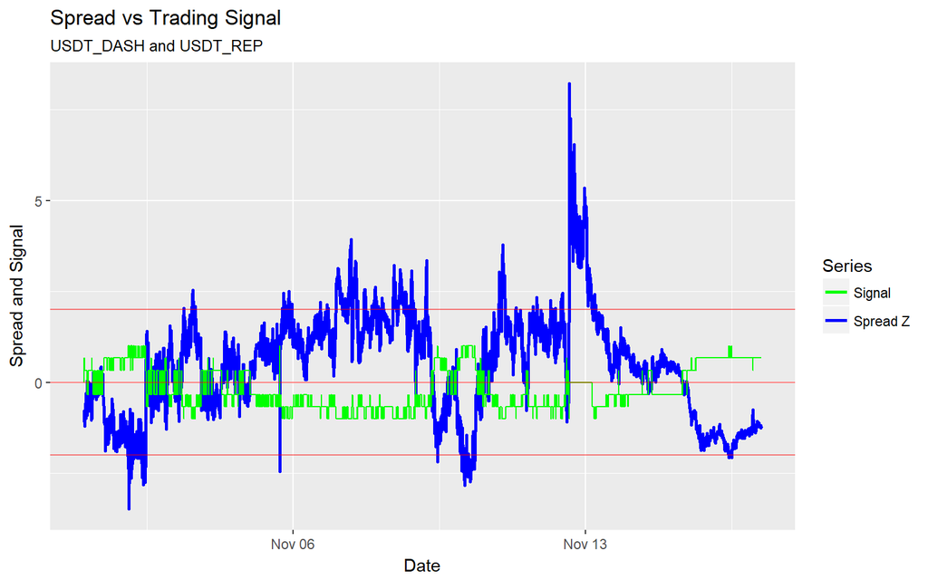

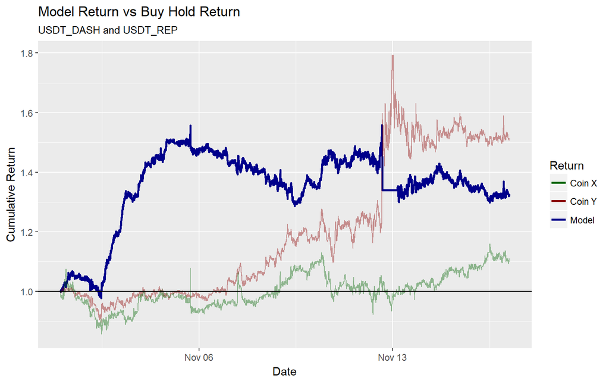

```
## [1] "Creating plots for USDT_XMR and USDT_DASH."
## [1] "Using train set from 2017-10-02 to 2017-11-01."
## [1] "Using test set from 2017-11-01 to 2017-11-21."
```

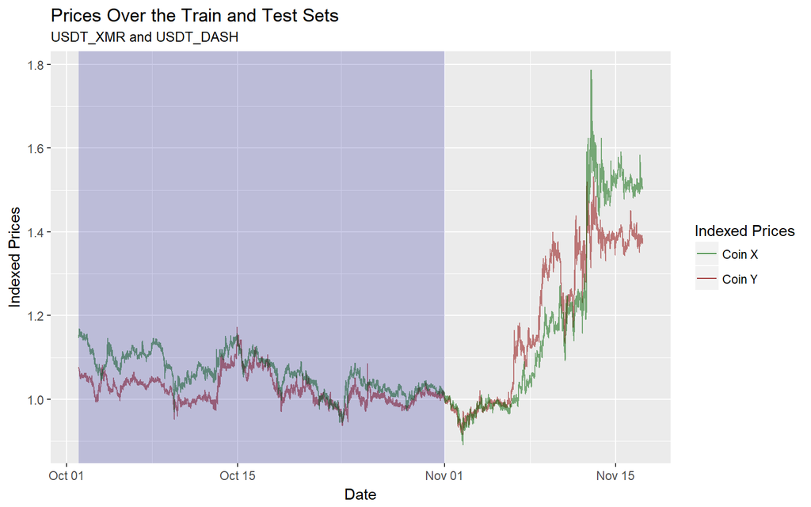

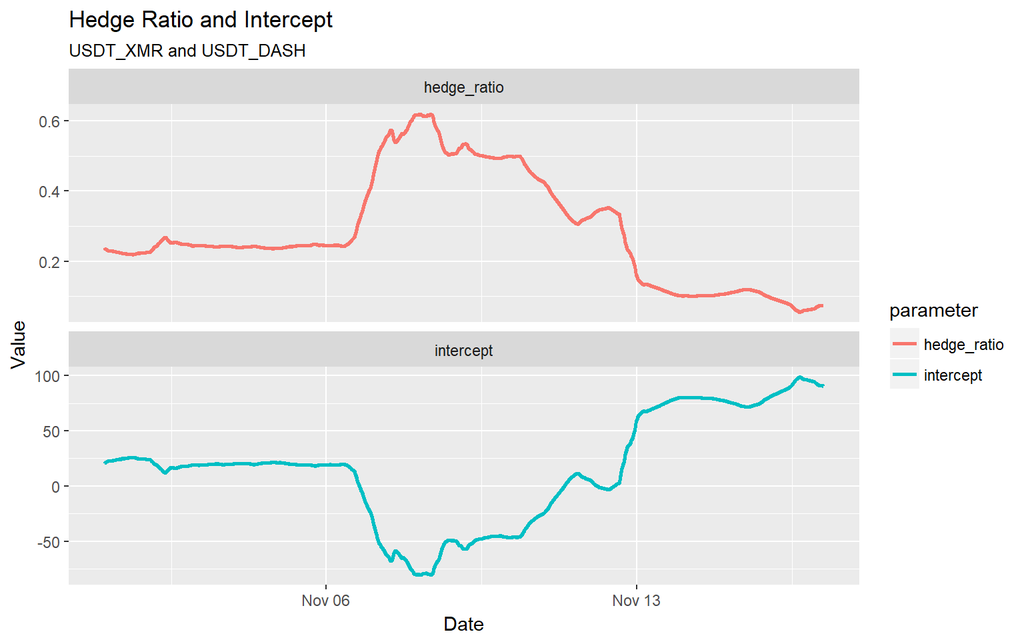

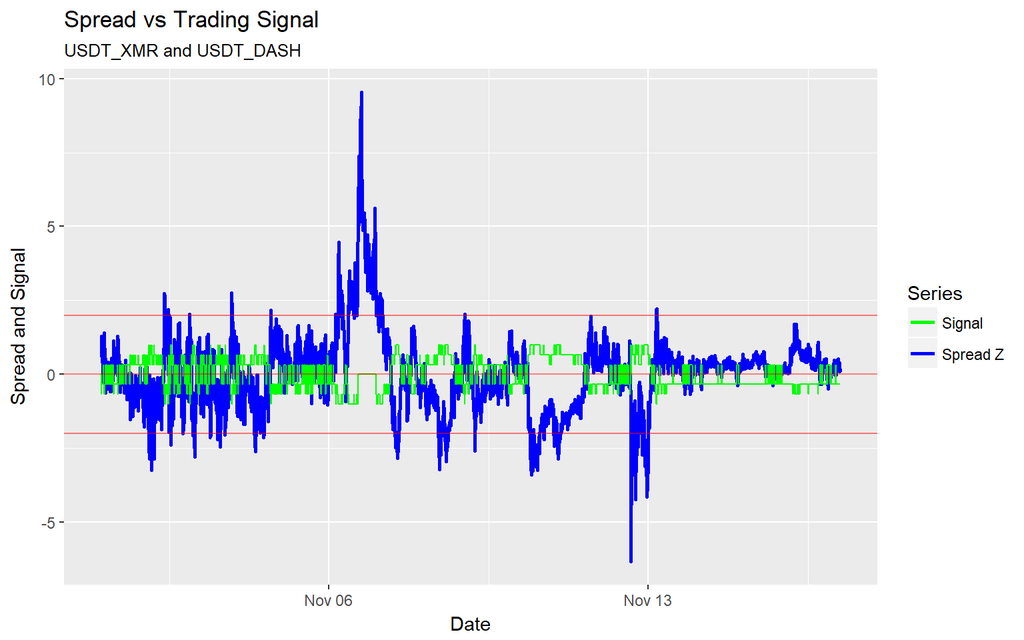

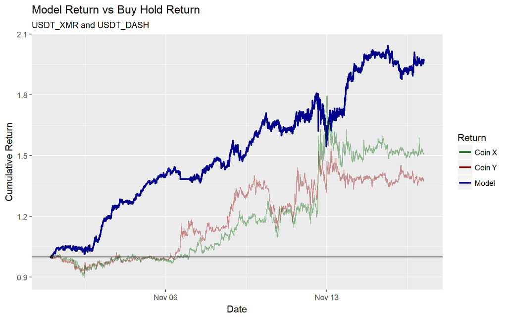

```
## [1] "Creating plots for USDT_XMR and USDT_ETH."
## [1] "Using train set from 2017-10-02 to 2017-11-01."
## [1] "Using test set from 2017-11-01 to 2017-11-21."
```

[49 more figures not shown]

```r
if (args_prediciton == "none") {
  plot_many(pricing_data = pricing_data,
            cutoff_date = cutoff_date,
            params = params,
            number_pairs = 100)
}
```